# Implementing OLS in R

## Figures For Asset Diversification

An investor would prefer asset $A$ to $B$ as $A$ has the same expected return as asset $B$ but is less risky. However, even though asset $A$ is less risky then asset $B$, including both assets in the portfolio may result in lower risk than holding asset $A$ alone. Suppose the investor creates a portfolio that invests fraction $\omega$ in asset $A$ and fraction $1-\omega$ in investment $B$. Then return on the portfolio is given by
$$r_P = \omega \cdot r_A + (1-\omega) \cdot r_B$$
Using the rules for expected value and variance of a sum from [Handout 1](https://edward-vytlacil.github.io/Econ136/Handouts/Handout_1_Review_Rules_Exp_Var_Spring_2024.pdf), we have that the expected value of the returns on the portfolio is given by
$$\mathbb{E}[r_P] = \omega \cdot \mathbb{E}[r_A] + (1-\omega) \cdot \mathbb{E}[r_B]$$
while the variance of the returns on the portfolio is given by}
$$\mbox{Var}(r_P) =\omega^2 \cdot \mbox{Var}(r_A)+(1-\omega)^2\cdot \mbox{Var}(r_B) + 2 \cdot \omega \cdot (1-\omega) \cdot \mbox{Cov}(r_A, r_B).$$
The variance of the portfolio (and the extent to which including asset $B$ in the portfolio diversifies risk) depends crucially on the covariance in returns. The smaller $\mbox{Cov}(r_A,r_B)$, the more including asset $B$ in the portfolio hedges the risk from assset $A$. If the correlation in returns is sufficiently high, then including both assets will not diversify risk. We now plot the variance of portfolio returns as a function of $\omega$ (fraction invested in asset $A$), for three alternative values of $\mbox{Cov}(r_A,r_B)$. Note that the code uses a user-defined function for the variance of returns on the portfolio.

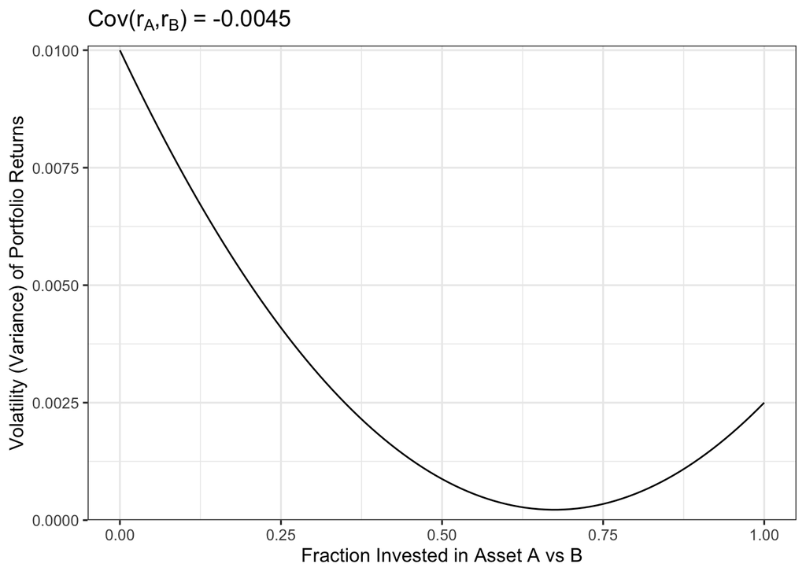

```r
# function returning variance of return on portfolio
# as function of omega and covariance of returns
f.var <- function(w,cov_AB){w^2*Var[1] +(1-w)^2*Var[2] +2* w *(1 - w)*cov_AB}

# suppose Cov(r_A,r_B)=-0.0045, negatively correlated returns.
ggplot(data.frame(x = c(0, 1)),   aes(x=x))+ theme_bw(base_size = 12)+
  stat_function(fun=f.var,args=list(cov_AB=-0.0045)) +
  labs(title=expression(paste("Cov(",r[A],",",r[B],") = -0.0045")))+
  scale_x_continuous(name="Fraction Invested in Asset A vs B",limits=c(0, 1))+
  scale_y_continuous(name="Volatility (Variance) of Portfolio Returns",limits=c(0,.01),expand = expansion(mult = c(0, 0.01)))
```

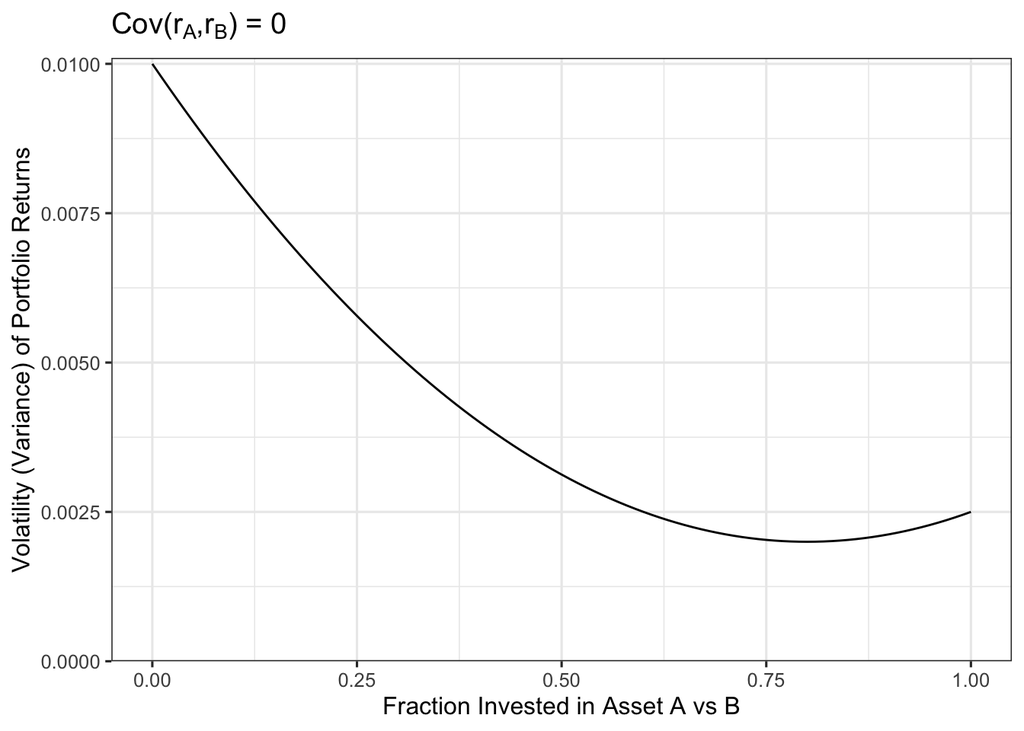

```r
# suppose Cov(r_A,r_B)=0, uncorrelated  returns.
ggplot(data.frame(x = c(0, 1)),   aes(x=x))+ theme_bw(base_size = 12)+
  stat_function(fun=f.var,args=list(cov_AB=0)) +
  labs(title=expression(paste("Cov(",r[A],",",r[B],") = 0")))+
  scale_x_continuous(name="Fraction Invested in Asset A vs B",limits=c(0, 1))+
  scale_y_continuous(name="Volatility (Variance) of Portfolio Returns",limits=c(0,.01),expand = expansion(mult = c(0, 0.01)))
```

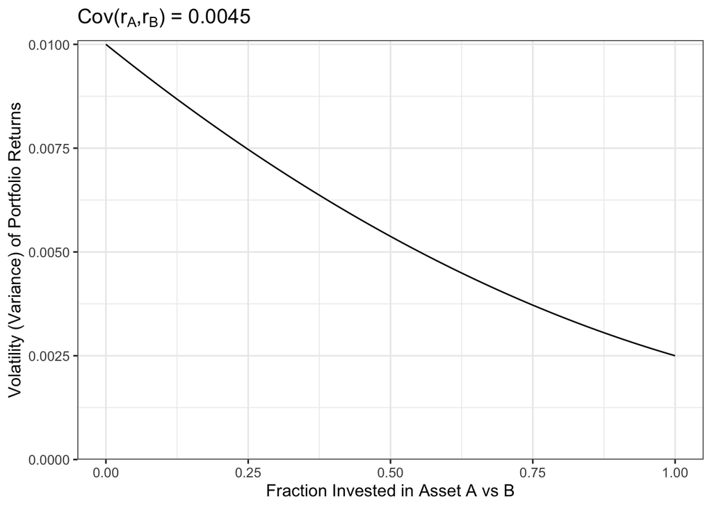

```r
# suppose Cov(r_A,r_B)=0.0045, positively correlated returns.
ggplot(data.frame(x = c(0, 1)),   aes(x=x))+ theme_bw(base_size = 12)+
  stat_function(fun=f.var,args=list(cov_AB=0.0045)) +
  labs(title=expression(paste("Cov(",r[A],",",r[B],") = 0.0045")))+
  scale_x_continuous(name="Fraction Invested in Asset A vs B",limits=c(0, 1))+
  scale_y_continuous(name="Volatility (Variance) of Portfolio Returns",limits=c(0,.01),expand = expansion(mult = c(0, 0.01)))
```

Now consider a portfolio that invests fraction fraction $\omega$ in asset $A$ and fraction $1-\omega$ in investment $C$:
$$r_P = \omega \cdot r_A + (1-\omega) \cdot r_C$$
Since $\mathbb{E}(r_A) \ne \mathbb{E}(r_C)$, both the expected return and the variance of returns on the portfolio depends on $\omega$. We now plot the expected returns and variance of returns as a function of $\omega$, using a different way to plot the figure in order to include both expected returns and variance of returns. In particular, we create a new data frame where each row corresponds to to a different value of $\omega$, and the columns include the expected return and variance of returns at that value of $\omega$. We create the figure supposing $\mbox{Cov}(r_A,r_C)=-0.0045$.

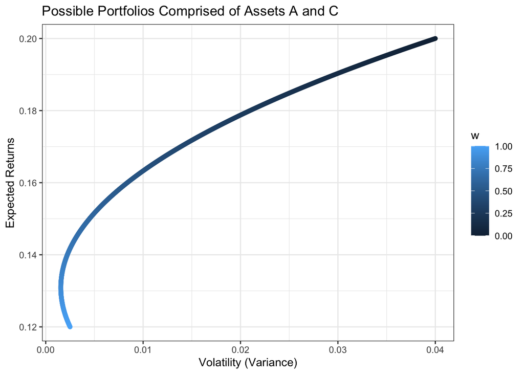

```r
omega <- seq(from = 0, to = 1, length.out = 1000)
er_A <- df[df$Asset=="A",]$Er
er_C <- df[df$Asset=="C",]$Er
var_A <- df[df$Asset=="A",]$Var
var_C <- df[df$Asset=="C",]$Var
covAC <- -0.0045
df2 <- data.frame(w = omega)
df2$er_p  <-  df2$w * er_A + (1-df2$w) * er_C
df2$var_p <-  df2$w^2*var_A +(1-df2$w)^2*var_C +2* df2$w *(1 - df2$w)*covAC

ggplot() + geom_point(data = df2,
                      aes(x = var_p, y = er_p, color = w)) +
  theme_bw() +
  ggtitle("Possible Portfolios Comprised of Assets A and C") +
  xlab("Volatility (Variance)") +
  ylab("Expected Returns")
```